# SnowMelt Decoder — Encoder Heads Greenland 2026

Vertikales Schmelzprofil (IMEI 300434065508020) — Decode, Diagnostik & Plots

Author

Thom Laepple

Published

September 24, 2026

Der **SnowMelt-Kopf** (IMEI **300434065508020**) steht vertikal im Schnee: 24 Knoten mit je NTC1 / NTC2 / NTC3 (TestSB), Abstand 4 cm. Dieses Dokument decodiert die `.bin`-Nachrichten und zeichnet das Schmelz-/Temperaturprofil. Die Kette (IMEI 301434062008130) hat ihr eigenes Dokument `decode_chain.qmd`. Die gemeinsamen Decode- und Kalibrierfunktionen liegen in `decode_core.R`.

```r
source("decode_core.R")
```

## Parameters

Edit this block, then re-render (`Ctrl+Shift+K`).

```r
# Identification is purely by IMEI — the "IMEI: <id>" line in the Cloudloop mail,
# which is also the .bin filename prefix (e.g. 300434065508020-2.bin). For a .bin
# attachment the IMEI is auto-detected from the filename; the head's n_nodes /
# fields / type / spacing then come from head_config[[IMEI]].
IMEI <- ""   # "" = auto-detect from BIN_FILE; set manually for a hex payload

# Path(s) to the .bin attachment(s) from the Cloudloop email ------------------
# One file → single decode. A VECTOR of files → a time series: the newest message
# drives the single-message sections (summary, table, profile), and ALL files
# feed the "Zeitlicher Verlauf" plot. All files must be the same head (same IMEI).
# -2 excluded: head was not yet erected at that time, so its profile is invalid.
BIN_FILE <- setdiff(Sys.glob("../testdata/300434065508020-*.bin"),
                    "../testdata/300434065508020-2.bin")

# OR paste hex payload(s) from the email (set IMEI above, leave BIN_FILE = "")--
MSG1 <- ""
MSG2 <- ""
```

```r
head_config <- list(
  # SnowMelt head, KEYED BY IMEI. `label` is a human name; n_nodes / fields /
  # type / spacing_cm are authoritative for decoding & plots. `calibration` =
  # path to a per-sensor lab table (position,node,ntc,a,b,c,d); NA → decode with
  # the universal mean lab-S4 curve.
  "300434065508020" = list(label = "Snowmelt NEWGRIP", n_nodes = 24L,
                 fields = c("ntc1", "ntc2", "testSB"),
                 type = "snowmelt", spacing_cm = 4L,
                 calibration = "../meta/GRIP_calibration_assignment.csv")
)

# --- Identify head by IMEI ---------------------------------------------------
bin_files <- BIN_FILE[nzchar(BIN_FILE)]
use_bin   <- length(bin_files) > 0L

imei <- if (IMEI != "") {
  IMEI
} else if (use_bin) {
  imeis <- unique(sub("-.*$", "", basename(bin_files)))
  if (length(imeis) > 1L)
    stop("BIN_FILE mixes IMEIs (", paste(imeis, collapse = ", "),
         ") — a time series must be one head.")
  imeis
} else {
  stop("Set IMEI (hex payload) or BIN_FILE (.bin attachment).")
}
cfg  <- head_config[[imei]]
if (is.null(cfg))
  stop(sprintf("IMEI '%s' is not in head_config (this is the SnowMelt document; the chain lives in decode_chain.qmd).", imei))

n_nodes <- cfg$n_nodes
fields  <- cfg$fields

# --- Per-sensor lab calibration (optional, keyed by head) --------------------
# NTC_s4 per sensor where a lab fit exists (and is numerically sane), else the
# universal mean lab-S4 curve (NTC_mean). See decode_core.R::calibrate_channel.
cal_path <- cfg$calibration
lab_cal  <- load_lab_cal(cal_path, n_nodes)     # nested [field][position] coefs, or NULL

n_lab_sensors <- if (is.null(lab_cal)) 0L else
  sum(sapply(names(lab_cal), function(ch)
    if (ch %in% fields) sum(!vapply(lab_cal[[ch]], is.null, logical(1))) else 0L))
n_ntc_sensors <- n_nodes * sum(fields %in% names(ntc_channel))
cal_method <- if (is.null(lab_cal)) "Mittlere Lab-S4-Kurve (universeller Fallback)" else
  sprintf("Lab-S4 pro Sensor (%d/%d) mit Mean-S4-Fallback", n_lab_sensors, n_ntc_sensors)

# --- File-size sanity check (sep vs nosep variant) ---------------------------
if (!use_bin) {
  n_hex_node   <- sum(ifelse(fields %in% c("ntc1", "ntc2", "testSB", "pressure"), 6L, 4L))
  expected_hex <- 8L + 6L + n_nodes * n_hex_node + 4L
} else {
  exp_len <- bin_expected_len(n_nodes, fields)
  for (bf in bin_files) {
    n_file  <- file.info(bf)$size
    surplus <- n_file - exp_len$sep
    ok <- n_file == exp_len$nosep || (surplus >= 0L && surplus <= n_nodes)
    if (!ok)
      warning(sprintf("%s is %d B but IMEI %s (%s) implies %d B (with) or %d B (without separators) for %d nodes — check head_config",
                      basename(bf), n_file, imei, paste(fields, collapse = "/"),
                      exp_len$sep, exp_len$nosep, n_nodes))
    else if (surplus > 0L)
      message(sprintf("%s is %d B (+%d over %d) — likely a defective sensor sending an oversized value; affected field(s) will read NA.",
                      basename(bf), n_file, surplus, exp_len$sep))
  }
}
```

## Decode

```r
library(dplyr)
library(tidyr)
library(ggplot2)
library(patchwork)

if (use_bin) {
  # ---- Binary snowchain path ------------------------------------------------
  # Decode every file, order oldest → newest. The NEWEST message is the "primary"
  # one shown in the single-message sections; all feed "Zeitlicher Verlauf".
  all_bin <- lapply(bin_files, read_snowchain_bin, fields = fields, n_nodes = n_nodes)
  ord       <- order(sapply(all_bin, `[[`, "time_unix"))
  all_bin   <- all_bin[ord]
  bin_files <- bin_files[ord]
  n_msg     <- length(all_bin)

  bin          <- all_bin[[n_msg]]
  primary_file <- bin_files[n_msg]
  time_utc   <- unix2utc(bin$time_unix)
  adc_temp_C <- adc2temp(bin$adc_temp)
  battery_mv <- bin$battery_mv
  battery_lo <- bin$battery_lo
  battery_hi <- bin$battery_hi
  battery_partial <- bin$battery_partial
  bin_fmt    <- if (bin$has_sep) "0x7C-separated" else "no separators"

  nodes <- bin_to_nodes(bin, fields, lab_cal)

} else {
  # ---- Hex email path -------------------------------------------------------
  hex <- toupper(trimws(paste0(MSG1, MSG2)))

  if (nchar(hex) == 0) {
    cat("No payload — set BIN_FILE or paste hex into MSG1 / MSG2 above and re-render.\n")
    knitr::knit_exit()
  }

  if (nchar(hex) != expected_hex) {
    warning(sprintf(
      "Expected %d hex chars (%d bytes) for IMEI %s, got %d. Payload may be incomplete.",
      expected_hex, expected_hex %/% 2L, imei, nchar(hex)
    ))
  }

  schema <- build_schema(n_nodes, fields)
  raw    <- decode_hex(schema, hex)

  time_utc   <- unix2utc(raw$time_unix)
  adc_temp_C <- adc2temp(raw$adc_temp)
  battery_mv <- as.integer(raw$battery_mv)
  battery_lo <- battery_mv; battery_hi <- battery_mv; battery_partial <- FALSE
}
```

## Diagnostics

```r
check <- function(val, lo, hi, label, unit) {
  ok  <- !is.na(val) && val >= lo && val <= hi
  col <- if (ok) "#2ecc71" else "#e74c3c"
  tag <- if (ok) "OK" else "CHECK"
  cat(sprintf('<span style="color:%s">%s</span>  **%s**: %.1f %s  *(expected %g – %g)*\n\n',
              col, tag, label, val, unit, lo, hi))
}
```

**NoteMessage summary — Snowmelt NEWGRIP (IMEI 300434065508020)**

| **Time (UTC)** | 2026-09-24 10:15:57 |
| --- | --- |
| **Battery** | 6656–6911 mV (low byte lost — defective-sensor shift) |
| **ADC temp** | -33.54 °C |
| **Kalibrierung** | Lab-S4 pro Sensor (72/72) mit Mean-S4-Fallback |
| **Source** | binary: 300434065508020-rb2609241015.bin (no separators) |
| **Messages loaded** | 518 file(s) — newest shown below; see Zeitlicher Verlauf for the series |

```r
check(battery_mv,  5500, 7200, "Battery",  "mV")
```

OK **Battery**: 6656.0 mV *(expected 5500 – 7200)*

```r
check(adc_temp_C, -60,   40,   "ADC temp", "°C")
```

OK **ADC temp**: -33.5 °C *(expected -60 – 40)*

## Node data

```r
if (!use_bin) {
  # Build nodes dataframe from hex-decoded raw list
  ntc_fields <- fields[fields != "gnd"]
  gnd_field  <- if ("gnd" %in% fields) "gnd" else NULL

  nodes <- data.frame(node = seq_len(n_nodes))

  for (f in ntc_fields) {
    col_raw <- paste0("n", nodes$node, ".", f)
    cnts    <- sapply(col_raw, function(nm) raw[[nm]])
    nodes[[paste0(f, "_counts")]] <- cnts          # raw counts (pre-calibration)
    if (f == "pressure") nodes$pressure_hPa  <- pressure2hPa(cnts)
    else                 nodes[[paste0(f, "_C")]] <- calibrate_channel(cnts, f, lab_cal)
  }

  if (!is.null(gnd_field)) {
    col_raw <- paste0("n", nodes$node, ".gnd")
    nodes$gnd <- sapply(col_raw, function(nm) raw[[nm]])
  }
}

# CSV gets the raw counts too; the on-page table stays calibrated for readability.
src_label <- if (use_bin) basename(primary_file) else cfg$label
knitr::kable(nodes |> select(-ends_with("_counts")), digits = 2,
             caption = sprintf("All nodes — %s | %s UTC",
                               src_label, format(time_utc, "%Y-%m-%d %H:%M")))
```

All nodes — 300434065508020-rb2609241015.bin | 2026-09-24 10:15 UTC

| node | ntc1_C | ntc2_C | testSB_C |
| --- | --- | --- | --- |
| 1 | -26.02 | -26.81 | -27.67 |
| 2 | -28.42 | -29.30 | -31.20 |
| 3 | -35.39 | -39.62 | -39.56 |
| 4 | -39.39 | -39.33 | -39.30 |
| 5 | -39.20 | -39.16 | -39.02 |
| 6 | -39.30 | -38.99 | -38.92 |
| 7 | -38.97 | -38.99 | -39.05 |
| 8 | -39.07 | -39.03 | -39.02 |
| 9 | -38.90 | -38.83 | -38.83 |
| 10 | -38.91 | -38.83 | -38.67 |
| 11 | -38.83 | -38.79 | -38.84 |
| 12 | -38.83 | -38.82 | -38.98 |
| 13 | -38.80 | -38.75 | -38.76 |
| 14 | -38.76 | -38.73 | -38.72 |
| 15 | -38.62 | -38.60 | -38.87 |
| 16 | -38.66 | -38.46 | -38.76 |
| 17 | -38.58 | -38.45 | -38.56 |
| 18 | -38.42 | -38.42 | -38.58 |
| 19 | -38.15 | -38.08 | -38.32 |
| 20 | -38.22 | -38.08 | -38.00 |
| 21 | -38.15 | -38.12 | -38.12 |
| 22 | -38.10 | -38.03 | -37.86 |
| 23 | -37.98 | -38.00 | -37.94 |
| 24 | -38.06 | -37.86 | NA |

## Profil

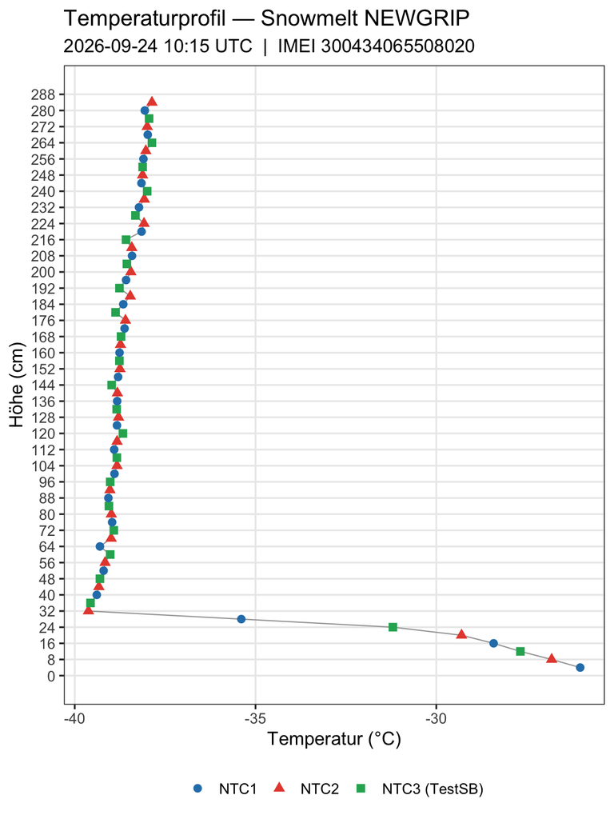

```r
# NTC rank within node: NTC1=1, NTC2=2, TestSB=3; height = (node-1)*3*s + rank*s
s <- cfg$spacing_cm
long <- nodes |>
  select(node, ends_with("_C")) |>
  pivot_longer(ends_with("_C"), names_to = "sensor", values_to = "temp_C") |>
  filter(!is.na(temp_C)) |>          # drop defective sensors (sentinel → NA, e.g. topmost NTC3)
  mutate(
    sensor   = recode(sensor, ntc1_C = "NTC1", ntc2_C = "NTC2", testSB_C = "NTC3 (TestSB)"),
    ntc_rank = case_when(sensor == "NTC1" ~ 1L, sensor == "NTC2" ~ 2L, TRUE ~ 3L),
    hoehe_cm = (node - 1L) * 3L * s + ntc_rank * s
  )

max_h <- n_nodes * 3L * s
ggplot(long, aes(x = temp_C, y = hoehe_cm)) +
  geom_path(data = arrange(long, hoehe_cm), colour = "grey65", linewidth = 0.4) +
  geom_point(aes(colour = sensor, shape = sensor), size = 2.5) +
  scale_y_continuous(
    name   = "Höhe (cm)",
    limits = c(0, max_h),
    breaks = seq(0, max_h, by = max(s, 8L))
  ) +
  scale_x_continuous(name = "Temperatur (°C)") +
  scale_colour_manual(values = c(NTC1 = "#2980b9", NTC2 = "#e74c3c",
                                 "NTC3 (TestSB)" = "#27ae60")) +
  labs(
    title    = sprintf("Temperaturprofil — %s", cfg$label),
    subtitle = sprintf("%s UTC  |  IMEI %s", format(time_utc, "%Y-%m-%d %H:%M"), imei),
    colour   = NULL, shape = NULL
  ) +
  theme_bw(base_size = 13) +
  theme(legend.position = "bottom", panel.grid.minor = element_blank())
```

## Zeitlicher Verlauf

Only shown when more than one `.bin` file is loaded (a time series). Every message contributes; the single-message sections above show the newest one.

Die Heatmap und der Linienplot zeigen **alle** Daten (das Tape-/Folien-Experiment an Knoten 6–8, 02.–12.07., ist dort sichtbar); die **Varianz-** und **Mittel−Trend-Kurven** rechnen ohne dieses Fenster, sonst wären sie verfälscht.

```r
multi <- use_bin && exists("all_bin") && n_msg > 1L
```

```r
# Long table across all messages: one row per (time, node, sensor), carrying
# both the calibrated temperature and the raw counts (pre-calibration).
series_wide <- bind_rows(lapply(all_bin, function(b)
  bin_to_nodes(b, fields, lab_cal) |> mutate(time = unix2utc(b$time_unix))))

temp_l <- series_wide |> select(node, time, ends_with("_C")) |>
  pivot_longer(ends_with("_C"), names_to = "sensor", values_to = "temp_C")
cnt_l  <- series_wide |> select(node, time, ends_with("_counts")) |>
  pivot_longer(ends_with("_counts"), names_to = "sensor", values_to = "counts") |>
  mutate(sensor = sub("_counts$", "_C", sensor))

series_long <- left_join(temp_l, cnt_l, by = c("node", "time", "sensor")) |>
  filter(!is.na(temp_C))

# Tape-/Alufolie-Experiment (Knoten 6–8, 02.07. 22:00 – 12.07. 22:00 UTC): die
# manipulierten (Knoten, Zeit)-Paare verfälschen jede Statistik. ALLE Diagnostiken
# rechnen deshalb auf `series_diag` (Experimentfenster ausgeschnitten); die volle
# Reihe `series_long` bleibt für die Plots und den Experiment-Abschnitt unten.
EXP_NODES <- c(6L, 7L, 8L)
EXP_WIN   <- as.POSIXct(c("2026-07-02 22:00", "2026-07-12 22:00"), tz = "UTC")
series_diag <- series_long |>
  filter(!(node %in% EXP_NODES & time >= EXP_WIN[1] & time <= EXP_WIN[2]))
```

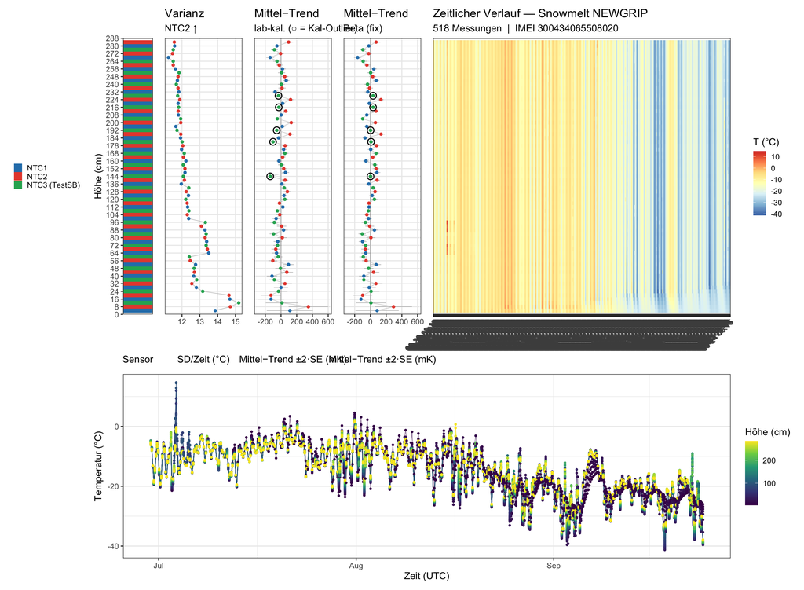

```r
# Two stacked panels over the same time series:
#  (top)    Hovmöller heatmap — Höhe (same axis as the profile plot) × time,
#           fill = temperature. Each measurement is one evenly-spaced column.
#  (bottom) Line plot — temperature vs real time, one line per sensor height,
#           coloured by Höhe; reads the diurnal cooling directly.
s   <- cfg$spacing_cm
ts  <- series_long |>
  mutate(
    sensor    = recode(sensor, ntc1_C = "NTC1", ntc2_C = "NTC2", testSB_C = "NTC3 (TestSB)"),
    ntc_rank  = case_when(sensor == "NTC1" ~ 1L, sensor == "NTC2" ~ 2L, TRUE ~ 3L),
    hoehe_cm  = (node - 1L) * 3L * s + ntc_rank * s,
    height_id = paste(node, sensor)
  )
tlevels <- format(sort(unique(ts$time)), "%m-%d %H:%M")
ts  <- ts |> mutate(tlab = factor(format(time, "%m-%d %H:%M"), levels = tlevels))
max_h <- n_nodes * 3L * s

# Companion strip (left of the heatmap, same y-axis): sensor type at each height.
sensor_cols <- c(NTC1 = "#2980b9", NTC2 = "#e74c3c", "NTC3 (TestSB)" = "#27ae60")
strip_df <- expand.grid(node = seq_len(n_nodes), ntc_rank = 1:3) |>
  mutate(sensor   = factor(c("NTC1", "NTC2", "NTC3 (TestSB)")[ntc_rank],
                           levels = names(sensor_cols)),
         hoehe_cm = (node - 1L) * 3L * s + ntc_rank * s)

p_sensor <- ggplot(strip_df, aes(x = 1, y = hoehe_cm, fill = sensor)) +
  geom_tile() +
  scale_fill_manual(values = sensor_cols, name = NULL) +
  scale_y_continuous(name = "Höhe (cm)", limits = c(0, max_h),
                     breaks = seq(0, max_h, by = max(s, 8L)), expand = c(0, 0)) +
  scale_x_continuous(name = "Sensor", breaks = NULL, expand = c(0, 0)) +
  labs(title = " ", subtitle = " ") +
  theme_bw(base_size = 13) +
  theme(panel.grid = element_blank(), legend.position = "left",
        legend.key.size = unit(0.8, "lines"))

# Two companion curves on the same height axis (variance & mean−trend residual).
# Beide rechnen OHNE das Tape-/Folien-Fenster (ts_diag), die Plots zeigen alles.
sensor_by_h <- strip_df |> select(hoehe_cm, sensor)

ts <- ts |> mutate(temp_beta = NTC_beta(counts))
ts_diag <- ts |> filter(!(node %in% EXP_NODES & time >= EXP_WIN[1] & time <= EXP_WIN[2]))

var_df <- ts_diag |> group_by(hoehe_cm) |>
  summarise(sd_t = 1.4826 * mad(temp_C, na.rm = TRUE), .groups = "drop") |>
  left_join(sensor_by_h, by = "hoehe_cm") |> arrange(hoehe_cm)

# Mittel−Trend = per-height time-median minus a single LINEAR height trend, once
# with the lab calibration and once with the fixed Beta curve (from counts).
lin_offset <- function(col) {
  d <- ts_diag |> select(time, hoehe_cm, y = all_of(col)) |> filter(is.finite(y)) |>
    group_by(time) |> mutate(r = 1000 * (y - fitted(lm(y ~ hoehe_cm)))) |> ungroup()
  d |> group_by(hoehe_cm) |>
    summarise(off_mK = mean(r), se_mK = sd(r) / sqrt(n()), .groups = "drop") |>
    left_join(sensor_by_h, by = "hoehe_cm")
}
off_lab  <- lin_offset("temp_C")
off_beta <- lin_offset("temp_beta")
xr_off   <- range(c(off_lab$off_mK  + 2 * off_lab$se_mK,  off_lab$off_mK  - 2 * off_lab$se_mK,
                    off_beta$off_mK + 2 * off_beta$se_mK, off_beta$off_mK - 2 * off_beta$se_mK),
                  na.rm = TRUE)

ybreaks <- seq(0, max_h, by = max(s, 8L))
p_var <- ggplot(var_df, aes(sd_t, hoehe_cm)) +
  geom_path(colour = "grey75", linewidth = 0.3) +
  geom_point(aes(colour = sensor), size = 1.5) +
  scale_colour_manual(values = sensor_cols, guide = "none") +
  scale_y_continuous(name = NULL, limits = c(0, max_h), breaks = ybreaks, expand = c(0, 0)) +
  scale_x_continuous(name = "SD/Zeit (°C)") +
  labs(title = "Varianz", subtitle = "NTC2 ↑") +
  theme_bw(base_size = 13) +
  theme(axis.text.y = element_blank(), axis.ticks.y = element_blank(),
        panel.grid.minor = element_blank())

# NTC3 calibration outliers (nodes 71/77/80/50/51/26) at their NTC3-row heights.
cal_outlier_h <- c(144, 180, 192, 216, 228, 288)

mk_mean <- function(d, ttl, sub) {
  out <- d |> filter(hoehe_cm %in% cal_outlier_h)
  ggplot(d, aes(off_mK, hoehe_cm)) +
    geom_vline(xintercept = 0, colour = "grey60", linewidth = 0.3) +
    geom_errorbarh(aes(xmin = off_mK - 2 * se_mK, xmax = off_mK + 2 * se_mK),
                   height = 0, colour = "grey70", linewidth = 0.3) +
    geom_path(colour = "grey80", linewidth = 0.3) +
    geom_point(aes(colour = sensor), size = 1.5) +
    geom_point(data = out, shape = 21, size = 3.6, stroke = 0.9,
               colour = "black", fill = NA) +
    scale_colour_manual(values = sensor_cols, guide = "none") +
    scale_y_continuous(name = NULL, limits = c(0, max_h), breaks = ybreaks, expand = c(0, 0)) +
    scale_x_continuous(name = "Mittel−Trend ±2·SE (mK)", limits = xr_off) +
    labs(title = ttl, subtitle = sub) +
    theme_bw(base_size = 13) +
    theme(axis.text.y = element_blank(), axis.ticks.y = element_blank(),
          panel.grid.minor = element_blank())
}
p_mean_lab  <- mk_mean(off_lab,  "Mittel−Trend", "lab-kal. (○ = Kal-Outlier)")
p_mean_beta <- mk_mean(off_beta, "Mittel−Trend", "Beta (fix)")

p_heat <- ggplot(ts, aes(x = tlab, y = hoehe_cm, fill = temp_C)) +
  geom_tile() +
  scale_fill_distiller(palette = "RdYlBu", direction = -1, name = "T (°C)") +
  scale_y_continuous(name = NULL, limits = c(0, max_h),
                     breaks = seq(0, max_h, by = max(s, 8L)), expand = c(0, 0)) +
  labs(title    = sprintf("Zeitlicher Verlauf — %s", cfg$label),
       subtitle = sprintf("%d Messungen  |  IMEI %s", n_msg, imei),
       x = NULL) +
  theme_bw(base_size = 13) +
  theme(axis.text.x = element_text(angle = 45, hjust = 1),
        axis.text.y = element_blank(), axis.ticks.y = element_blank(),
        panel.grid  = element_blank())

p_line <- ggplot(ts, aes(x = time, y = temp_C,
                         group = height_id, colour = hoehe_cm)) +
  geom_line(alpha = 0.5, linewidth = 0.4) +
  geom_point(size = 1) +
  scale_colour_viridis_c(name = "Höhe (cm)") +
  labs(x = "Zeit (UTC)", y = "Temperatur (°C)") +
  theme_bw(base_size = 13)

(p_sensor + p_var + p_mean_lab + p_mean_beta + p_heat +
   plot_layout(widths = c(0.5, 1.3, 1.3, 1.3, 5))) / p_line +
  plot_layout(heights = c(3, 2))
```

## Einschneidiagnostik

Wird das untere Ende der Kette vom Schnee eingegraben? Kriterium ist die **Dämpfung des Tagesgangs**: die Dämpfungstiefe der Tageswelle in trockenem Schnee beträgt ~8–10 cm, ein Sensor unter ≥5 cm Schnee verliert also sichtbar Tagesamplitude, unter ~20 cm bleiben <10 %. Die **Referenz ist die Atmosphäre selbst**: die obersten 25 % der Sensorhöhen messen den ungedämpften Tagesgang am selben Tag mit, im Verhältnis Amplitude/Referenz kürzt sich die Wetterlage heraus. Deshalb genügt **ein einziger voller Messtag** (≥ 4 Messungen über den Tag; Tage mit Referenzamplitude < 2 K — ruhig/bedeckt — werden übersprungen). Der Abschnitt rechnet bei jedem Render neu: (a) Hovmöller des Dämpfungsverhältnisses, (b) das Verhältnisprofil des jüngsten verwertbaren Tages, (c) ein automatisches Urteil (gedämpft = Verhältnis < 0.35).

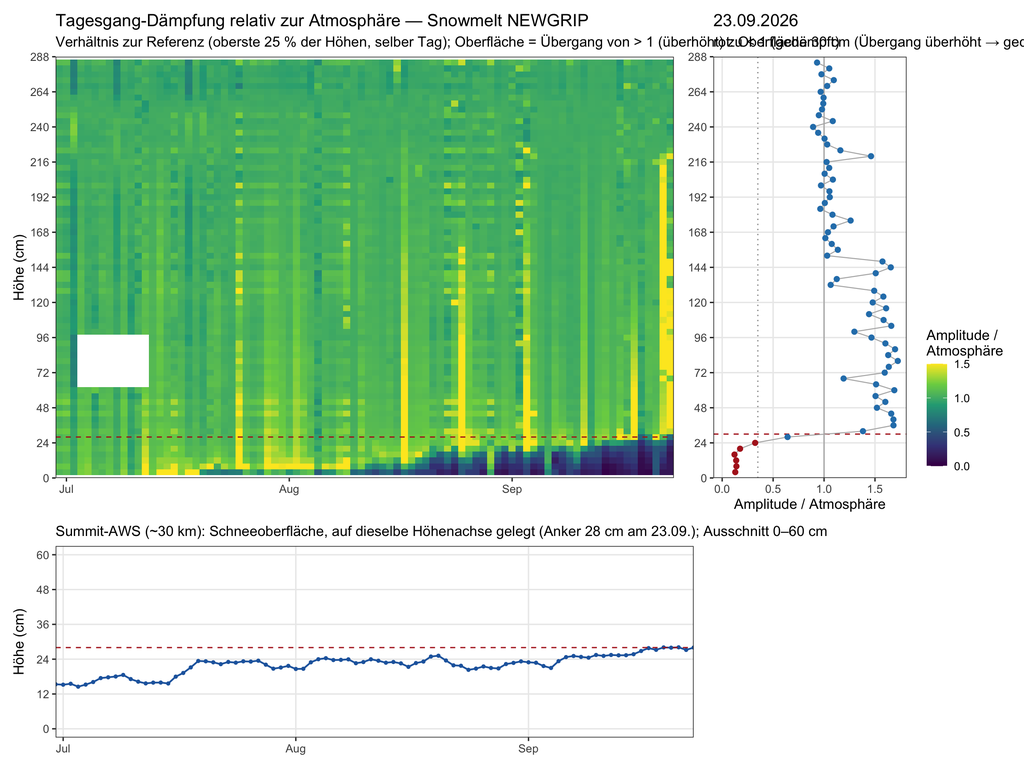

```r
s        <- cfg$spacing_cm
rank_map <- c(ntc1_C = 1L, ntc2_C = 2L, testSB_C = 3L)

amp_d <- series_diag |>
  mutate(hoehe_cm = (node - 1L) * 3L * s + rank_map[sensor] * s,
         day      = as.Date(time)) |>
  group_by(hoehe_cm, day) |>
  summarise(amp = diff(range(temp_C)), n_meas = n(), .groups = "drop") |>
  filter(n_meas >= 4L, day > min(day), day < max(day))   # nur volle Tage

# Referenz "Atmosphäre" = Median-Amplitude der obersten 25 % der Höhen AM SELBEN
# Tag; im Verhältnis kürzt sich die Wetterlage heraus → 1 voller Tag genügt.
h_ref <- quantile(unique(amp_d$hoehe_cm), 0.75)
ref_d <- amp_d |> group_by(day) |>
  summarise(ref = median(amp[hoehe_cm >= h_ref]), .groups = "drop")
ratio_d <- amp_d |> left_join(ref_d, by = "day") |>
  filter(ref >= 2) |>            # ruhige/bedeckte Tage (< 2 K oben): kein Urteil möglich
  mutate(ratio = amp / ref)

day_v  <- max(ratio_d$day)       # jüngster verwertbarer Tag
prof_v <- ratio_d |> filter(day == day_v) |> mutate(gedaempft = ratio < 0.35)

# Oberflächenlage aus dem Übergang überhöht -> gedämpft. Der Sensor unmittelbar
# über der Schneefläche zeigt einen ÜBERHÖHTEN Tagesgang (die Fläche ist die
# strahlende Oberfläche), der erste darunter einen gedämpften. Der Wechsel
# lokalisiert die Oberfläche auf den Knotenabstand genau, ohne Dämpfungstiefe
# und ohne Extrapolation.
h_uebergang <- function(h, r, h_max = h_ref) {
  ue <- h[r > 1.05 & h < h_max]
  if (!length(ue)) return(list(h_gd = NA_real_, h_ue = NA_real_, h_surf = NA_real_,
                               n_gd = NA_integer_))
  h_ue <- min(ue); gd <- h[r < 0.95 & h < h_ue]
  h_gd <- if (length(gd)) max(gd) else NA_real_
  list(h_gd = h_gd, h_ue = h_ue, h_surf = (h_gd + h_ue)/2,
       n_gd = sum(r < 0.95 & h < h_ue))
}
tr_v <- h_uebergang(prof_v$hoehe_cm, prof_v$ratio)

max_h <- n_nodes * 3L * s
p_hov <- ggplot(ratio_d, aes(day, hoehe_cm, fill = pmin(ratio, 1.5))) +
  geom_tile() +
  scale_fill_viridis_c(name = "Amplitude /\nAtmosphäre", limits = c(0, 1.5)) +
  scale_y_continuous("Höhe (cm)", limits = c(0, max_h),
                     breaks = seq(0, max_h, 24), expand = c(0, 0)) +
  scale_x_date(NULL, expand = c(0, 0)) +
  labs(title    = sprintf("Tagesgang-Dämpfung relativ zur Atmosphäre — %s", cfg$label),
       subtitle = "Verhältnis zur Referenz (oberste 25 % der Höhen, selber Tag); Oberfläche = Übergang von > 1 (überhöht) zu < 1 (gedämpft)") +
  theme_bw(base_size = 12) + theme(panel.grid = element_blank())

p_prof <- ggplot(prof_v, aes(ratio, hoehe_cm)) +
  geom_vline(xintercept = 1, colour = "grey70") +
  geom_vline(xintercept = 0.35, linetype = "dotted", colour = "grey60") +
  { if (is.finite(tr_v$h_surf)) geom_hline(yintercept = tr_v$h_surf,
        linetype = "dashed", colour = "firebrick") } +
  geom_path(colour = "grey70", linewidth = 0.4) +
  geom_point(aes(colour = gedaempft), size = 1.8, show.legend = FALSE) +
  scale_colour_manual(values = c(`FALSE` = "#2980b9", `TRUE` = "firebrick")) +
  scale_y_continuous(NULL, limits = c(0, max_h), breaks = seq(0, max_h, 24),
                     expand = c(0, 0)) +
  scale_x_continuous("Amplitude / Atmosphäre", limits = c(0, NA)) +
  labs(title = format(day_v, "%d.%m.%Y"),
       subtitle = if (is.finite(tr_v$h_surf))
         sprintf("rot: Oberfläche %.0f cm (Übergang überhöht → gedämpft)", tr_v$h_surf)
       else "punktiert: alte Dämpfungsschwelle 0.35") +
  theme_bw(base_size = 12) + theme(panel.grid.minor = element_blank())

# --- Oberflächenlage aus dem Amplituden- und Phasenprofil ------------------
# Harmonische Regression (Tageswelle) je Sensorhöhe über die letzten 7 Tage:
# T = m + A sin(wt+phi). ln(A) fällt linear mit der Tiefe -> Steigung = 1/d
# (Dämpfungstiefe), und die Höhe, bei der die Gerade die Luftamplitude
# erreicht, ist die Schneeoberfläche auf der Kettenachse.
om <- 2*pi/86400
fitA <- series_diag |>
  mutate(hoehe_cm = (node - 1L) * 3L * s + rank_map[sensor] * s,
         ts = as.numeric(time)) |>
  filter(time > max(time) - 7*86400) |>
  group_by(hoehe_cm) |>
  summarise(cf = list(coef(lm(temp_C ~ sin(om*ts) + cos(om*ts)))), .groups = "drop") |>
  mutate(A = sapply(cf, function(c) sqrt(c[2]^2 + c[3]^2)),
         phi = sapply(cf, function(c) atan2(c[3], c[2]))) |>
  select(-cf) |> arrange(hoehe_cm)
A_air <- median(fitA$A[fitA$hoehe_cm >= h_ref]); phi_air <- median(fitA$phi[fitA$hoehe_cm >= h_ref])
fitA <- fitA |> mutate(rA = A/A_air, lag_h = ((phi_air - phi) %% (2*pi))/om/3600)
tr7  <- h_uebergang(fitA$hoehe_cm, fitA$rA)
sub  <- fitA |> filter(rA < 0.75)
d_damp <- NA_real_; h_surf <- NA_real_
if (nrow(sub) >= 2) {
  lf <- lm(log(A) ~ hoehe_cm, data = sub)
  if (coef(lf)[2] > 0) {
    d_damp <- 1/coef(lf)[2]
    h_surf <- (log(A_air) - coef(lf)[1])/coef(lf)[2]
  }
}

# --- Summit-AWS auf dieselbe Höhenachse gelegt ------------------------------
# z_surf_combined der AWS, so verschoben, dass sie am Urteilstag die aus der
# Dämpfung bestimmte Oberflächenhöhe trifft -> direkt mit dem Hovmöller oben
# vergleichbar (gleiche Höhenachse in cm, Ausschnitt).
aws_url <- sprintf("https://thredds.geus.dk/thredds/fileServer/aws/l3sites/csv/day/%s_day.csv", "SUM")
aws_raw <- tryCatch({ options(timeout = 60)
  suppressWarnings(readr::read_csv(aws_url, show_col_types = FALSE)) },
  error = function(e) NULL)

p_aws <- NULL
if (!is.null(aws_raw) && "z_surf_combined" %in% names(aws_raw)) {
  aw <- aws_raw |> mutate(day = as.Date(time)) |>
    filter(day >= min(ratio_d$day), day <= max(ratio_d$day), is.finite(z_surf_combined)) |>
    group_by(day) |> summarise(z = 100*mean(z_surf_combined), .groups = "drop")
  if (nrow(aw)) {
    anchor <- if (is.finite(tr7$h_surf)) tr7$h_surf else
              if (is.finite(h_surf)) h_surf else min(fitA$hoehe_cm)
    z0 <- aw$z[which.min(abs(as.numeric(aw$day - day_v)))]
    aw <- aw |> mutate(h_chain = z - z0 + anchor)
    p_aws <- ggplot(aw, aes(day, h_chain)) +
      geom_line(colour = "#2166ac", linewidth = 0.7) +
      geom_point(colour = "#2166ac", size = 1) +
      { if (is.finite(anchor)) geom_hline(yintercept = anchor, linetype = "dashed",
                                          colour = "firebrick") } +
      scale_x_date(NULL, expand = c(0, 0),
                   limits = c(min(ratio_d$day), max(ratio_d$day))) +
      scale_y_continuous("Höhe (cm)", limits = c(0, 60), breaks = seq(0, 60, 12)) +
      labs(subtitle = sprintf("Summit-AWS (~30 km): Schneeoberfläche, auf dieselbe Höhenachse gelegt (Anker %.0f cm am %s); Ausschnitt 0–60 cm",
                              anchor, format(day_v, "%d.%m."))) +
      theme_bw(base_size = 12) + theme(panel.grid.minor = element_blank())
  }
}

if (is.finite(tr7$h_surf))
  p_hov <- p_hov + geom_hline(yintercept = tr7$h_surf, linetype = "dashed",
                              colour = "firebrick")

if (is.null(p_aws)) {
  p_hov + p_prof + plot_layout(widths = c(3.2, 1))
} else {
  (p_hov + p_prof + plot_layout(widths = c(3.2, 1))) /
    (p_aws + patchwork::plot_spacer() + plot_layout(widths = c(3.2, 1))) +
    plot_layout(heights = c(2.2, 1), guides = "collect") &
    theme(legend.position = "right")
}
```

```r
bot <- prof_v |> slice_min(hoehe_cm, n = 1)
stand <- format(day_v, "%d.%m.%Y")

if (is.finite(tr_v$h_surf)) {
  # Regelfall: der Übergang liegt innerhalb der Kette.
  cat(sprintf(
    "**Schneeoberfläche bei %.0f ± %.0f cm** auf der Kettenachse (Tages-Check %s). %d cm ist gedämpft (%.0f %% der Atmosphären-Referenz), %d cm überhöht (%.0f %%) — der Sensor unmittelbar über der Fläche sieht deren Tagesgang verstärkt, der erste darunter bereits gedämpft. Der Wechsel lokalisiert die Oberfläche auf den Knotenabstand genau; es geht weder eine Dämpfungstiefe noch eine Extrapolation ein. Gedämpft sind **%d von %d** Sensorhöhen darunter, das entspricht **%.0f cm Überdeckung** über dem untersten Sensor (%d cm).\n",
    tr_v$h_surf, s/2, stand, tr_v$h_gd, 100*prof_v$ratio[prof_v$hoehe_cm == tr_v$h_gd],
    tr_v$h_ue, 100*prof_v$ratio[prof_v$hoehe_cm == tr_v$h_ue],
    tr_v$n_gd, sum(prof_v$hoehe_cm < tr_v$h_ue),
    tr_v$h_surf - bot$hoehe_cm, bot$hoehe_cm))
} else if (bot$ratio >= 0.7) {
  cat(sprintf(
    "**Kein Sensor eingeschneit** (Tages-Check %s). Im Profil gibt es keinen Übergang überhöht → gedämpft; der unterste Sensor (%d cm) erreicht **%.0f %%** der Atmosphären-Referenz (%.1f von %.1f K) — keine Dämpfung, kein vertikaler Gradient. Eine Überdeckung von wenigen cm (≲ 5 cm) wäre nicht sicher erkennbar.\n",
    stand, bot$hoehe_cm, 100*bot$ratio, bot$amp, bot$ref))
} else {
  cat(sprintf(
    "**Grenzfall — kein Übergang im Profil** (Tages-Check %s). Im Profil gibt es keinen Übergang überhöht → gedämpft; der unterste Sensor (%d cm) erreicht **%.0f %%** der Referenz (%.1f von %.1f K). Entweder steht die Oberfläche unterhalb des Kettenendes, oder der Tag ist zu bedeckt für ein Urteil (ohne direkte Einstrahlung fehlt die Überhöhung).\n",
    stand, bot$hoehe_cm, 100*bot$ratio, bot$amp, bot$ref))
}
```

**Schneeoberfläche bei 30 ± 2 cm** auf der Kettenachse (Tages-Check 23.09.2026). 28 cm ist gedämpft (64 % der Atmosphären-Referenz), 32 cm überhöht (138 %) — der Sensor unmittelbar über der Fläche sieht deren Tagesgang verstärkt, der erste darunter bereits gedämpft. Der Wechsel lokalisiert die Oberfläche auf den Knotenabstand genau; es geht weder eine Dämpfungstiefe noch eine Extrapolation ein. Gedämpft sind **7 von 7** Sensorhöhen darunter, das entspricht **26 cm Überdeckung** über dem untersten Sensor (4 cm).

```r
# Gegenprobe mit der alten Schwellenregel. Die 35-%-Schwelle markiert nicht die
# Oberfläche, sondern eine Höhe rund eine Dämpfungstiefe darunter — sie setzt
# die Oberfläche deshalb systematisch zu tief und steht nur noch als Kontrolle.
if (any(prof_v$gedaempft)) {
  h_snow <- max(prof_v$hoehe_cm[prof_v$gedaempft])
  cat(sprintf(
    "\nZum Vergleich die frühere Schwellenregel: %d von %d Sensorhöhen liegen unter 35 %% der Referenz, die oberste davon bei %d cm. Diese Höhe liegt rund eine Dämpfungstiefe **unter** der Oberfläche und ist deshalb kein Oberflächenmaß.\n",
    sum(prof_v$gedaempft), nrow(prof_v), h_snow))
}
```

Zum Vergleich die frühere Schwellenregel: 6 von 71 Sensorhöhen liegen unter 35 % der Referenz, die oberste davon bei 24 cm. Diese Höhe liegt rund eine Dämpfungstiefe **unter** der Oberfläche und ist deshalb kein Oberflächenmaß.

```r
# Gegenprobe über das 7-Tage-Profil: Amplitude und Phase, jeweils mit ihrer
# EIGENEN Längenskala. Beide dürfen nicht dieselbe Dämpfungstiefe benutzen; die
# Amplitude fällt schneller, als der Verzug wächst. Die Ursache ist offen —
# eindringende Strahlung wurde geprüft und erklärt es nicht (siehe Abschnitt
# "Amplitude gegen Phase").
if (is.finite(h_surf) && is.finite(d_damp)) {
  bot_h <- min(fitA$hoehe_cm)
  lagb  <- fitA$lag_h[fitA$hoehe_cm == bot_h]
  subP  <- fitA |> filter(rA < 0.95, hoehe_cm < h_ref)
  d_ph  <- if (nrow(subP) >= 2) {
    cp <- coef(lm(lag_h*3600 ~ hoehe_cm, data = subP))[2]
    if (cp < 0) -1/(cp*om) else NA_real_ } else NA_real_
  cat(sprintf(
    "\n**Gegenprobe über das 7-Tage-Profil.** Aus der Amplitude: Abklinglänge **%.1f cm**, extrapoliert auf die Referenzamplitude ergibt **h = %.0f cm**. Aus dem Phasenverzug (%.1f h am untersten Sensor) mit der zugehörigen Längenskala %s: **%.0f cm Überdeckung**%s.\n",
    d_damp, h_surf, lagb,
    if (is.finite(d_ph)) sprintf("%.1f cm", d_ph) else "—",
    if (is.finite(d_ph)) lagb*3600*om*d_ph else NA_real_,
    if (is.finite(tr7$h_surf)) sprintf("; der Übergangsschätzer über dieselben 7 Tage setzt die Oberfläche auf %.0f cm", tr7$h_surf) else ""))
}
```

**Gegenprobe über das 7-Tage-Profil.** Aus der Amplitude: Abklinglänge **8.8 cm**, extrapoliert auf die Referenzamplitude ergibt **h = 29 cm**. Aus dem Phasenverzug (1.8 h am untersten Sensor) mit der zugehörigen Längenskala —: **NA cm Überdeckung**; der Übergangsschätzer über dieselben 7 Tage setzt die Oberfläche auf 28 cm.

```r
# Frühwarnung: fallendes Verhältnis am untersten Sensor über die letzten
# verwertbaren Tage = einsetzendes Einschneien, bevor die 35 %-Schwelle fällt.
r_bot <- ratio_d |> filter(hoehe_cm == min(hoehe_cm)) |> arrange(day) |> tail(5)
if (!is.finite(tr_v$h_surf) && nrow(r_bot) >= 3 &&
    tail(r_bot$ratio, 1) < 0.7 && tail(r_bot$ratio, 1) < head(r_bot$ratio, 1)) {
  cat(sprintf(
    "\n**Hinweis — beginnende Dämpfung:** das Verhältnis des untersten Sensors fällt über die letzten %d verwertbaren Tage (%s): %s. Das ist das erwartete Muster bei einsetzendem Einschneien; die 35 %%-Schwelle ist noch nicht unterschritten.\n",
    nrow(r_bot), paste(format(range(r_bot$day), "%d.%m."), collapse = " – "),
    paste(sprintf("%.2f", r_bot$ratio), collapse = " → ")))
}
```

### Was das Amplitudenprofil wirklich zeigt

Das Profil der Tagesamplitude ist **nicht monoton**. Über den letzten sieben Tagen (GRIP):

[output not shown]

**Der Übergang überhöht → gedämpft.** Die Oberfläche liegt zwischen dem untersten Sensor mit A/A_Referenz > 1 und dem obersten darunter mit A/A_Referenz < 1. Die Auflösung ist der Knotenabstand, 4 cm; es geht weder eine Dämpfungstiefe noch eine Extrapolation ein.

Über die letzten sieben Tage: **Oberfläche bei 28 ± 2 cm** auf der Kettenachse. 24 cm ist gedämpft (59 % der Referenz), 32 cm überhöht (126 %); **6 von 7** Sensorhöhen darunter sind gedämpft, also 24 cm Überdeckung über dem untersten Sensor (4 cm).

**Gegenprobe mit dem Detektor von Sledd et al. (2026).** Sie bestimmen die Oberfläche an einer 2-cm-Thermistorkette in der Perkolationszone Südwestgrönlands aus dem **Maximum der 24-Stunden- Varianz des Vertikalgradienten** ΔT/Δz (Profil je Zeitschritt vertikal normiert), weil die thermischen Eigenschaften von Luft und Schnee sich unterscheiden. Der Detektor braucht keine Überhöhung, sondern nur einen Tagesgang im Gradienten, und arbeitet damit auch an bedeckten Tagen. Auf unsere Daten angewendet:

Tagesmedian der letzten sieben Tage: **24–28 cm**. Sledd et al. brauchen zusätzlich einen empirisch bestimmten Versatz von +4 cm, den sie gegen eine Handmessung beim Abbau kalibriert haben; mit diesem Versatz ergäbe sich 28–32 cm. Der Übergangsschätzer kommt ohne Kalibrierung auf denselben Wert.

### Amplitude gegen Phase

`A ∝ e^{−z/d}` und `Verzug = z/(dω)` enthalten für eine rein diffusive Welle dieselbe Dämpfungstiefe. Gemessen fällt die Amplitude schneller, als der Verzug wächst. Der Betrag hängt allerdings vom gewählten Fenster ab:

| Fenster | n | d aus A (cm) | d aus Phase (cm) | Verhältnis | ρ aus A | ρ aus Phase |
| --- | --- | --- | --- | --- | --- | --- |
| 5 d bis 24.09. | 7 | 9.6 | 25.0 | 2.60 | 272 | NA |
| 7 d bis 24.09. | 6 | 8.8 | -93.9 | -10.69 | 222 | NA |
| 10 d bis 24.09. | 6 | 8.2 | 443.1 | 54.33 | 183 | NA |
| 14 d bis 24.09. | 6 | 7.0 | 18.9 | 2.72 | NA | NA |
| 21 d bis 24.09. | 5 | 8.2 | 15.5 | 1.89 | 187 | 713 |
| 7 d bis 20.09. | 6 | 6.8 | -578.3 | -85.16 | NA | NA |
| 7 d bis 16.09. | 5 | 8.2 | 15.7 | 1.93 | 186 | 735 |
| 7 d bis 12.09. | 5 | 10.4 | 7.3 | 0.70 | 327 | 123 |
| 7 d bis 08.09. | 5 | 168.7 | 139.6 | 0.83 | NA | NA |

**Der Betrag ist nicht insolationsgetrieben.** Über die letzten drei Wochen — in denen sich die Einschneitiefe kaum ändert — nach der Einstrahlung an der Summit-AWS geteilt, ergibt die sonnige Hälfte d_A = 9,8 cm gegen d_P = 12,4 cm (Verhältnis 1,3), die bedeckte Hälfte 9,5 gegen 11,0 cm (1,2). Eindringende Strahlung würde an sonnigen Tagen einen verzugsfreien Anteil beitragen und das Verhältnis dort vergrößern; das ist nicht der Fall.

Sledd et al. korrigieren an ihrer Kette eine **Eigenerwärmung**: sie misst unter der Oberfläche Temperaturen über 0 °C, absorbiert also mehr Strahlung als der umgebende Firn. Ihre Korrektur folgt Beer mit κ = 19 m⁻¹ (Abklinglänge 5,3 cm) und einem NIR-Anteil von 0,5 direkt unter der Oberfläche. Unsere Geometrie ist eine andere: die NTCs sitzen auf Auslegern quer zur Achse, die Schneedecke über dem Sensor ist ungestört, und es gibt kein 5 cm dickes Tragrohr im Strahlengang. Der Insolationstest ist damit vereinbar — die Eigenerwärmung, die ihre Auswertung dominiert, ist in unseren Daten nicht nachweisbar.

### Woher die Diskrepanz nicht kommt

**Mehrtägiges Wetter.** Das Residuum nach Abzug der Tageswelle ist kein Rauschen — das Instrument liegt unter 1 mK — sondern durchgelassenes synoptisches Signal. Ein 24-Stunden-Mittel über sechs gleichabständige Messungen entfernt die Tageswelle und alle Oberwellen exakt, lässt aber mehrtägige Variabilität passieren: 36 % bei 2 Tagen Periode, 17 % bei 3, 6 % bei 5. Mit einer Oberflächenamplitude von 5 K und einer Dämpfungstiefe von 15,7 cm für die 3-Tage-Welle ergibt das in 21 cm Tiefe 228 mK gegen 227 mK gemessen. Eine Simulation mit rotem Rauschen dieser Stärke zeigt: beide Schätzer bleiben erwartungstreu (10,0 bis 10,7 cm bei einer Wahrheit von 10), nur ihre Streuung wächst — ±24,5 cm bei einem 4-Tage-Fenster, ±0,9 cm bei 21 Tagen. Die Ausreißer der Fenstertabelle oben sind damit Streuung, kein Befund.

**Der Sensorrang.** Die Ränge NTC1, NTC2 und TestSB wechseln sich über die Tiefe ab, und NTC2 hat einen Tiefenversatz von 0,64 cm. Ohne NTC2 wird das Verhältnis größer (1,37 statt 1,25), mit korrigiertem NTC2 bleibt es bei 1,27.

**Eindringende Strahlung.** Nach Einstrahlung geteilt: sonnige Hälfte 1,3, bedeckte 1,2.

**Ein glatter κ-Gradient.** Die WKB-Lösung bindet Amplitude und Phase über dasselbe Integral aneinander; übrig bleibt der Vorfaktor κ^(−1/4). Selbst bei einem Dichteanstieg von 150 auf 400 kg/m³ über 20 cm gibt der nur ein Verhältnis von 1,10.

**Eine oberflächennahe Mischungsschicht** (Windpumpen). Sie läge oben; dort ist das Verhältnis aber 0,86.

### Wo sie herkommt

Die Diskrepanz ist nicht über die Tiefe verteilt, sondern sitzt in einem Intervall. Lokales d aus benachbarten Sensorpaaren, 21-Tage-Fenster:

| Paar | d aus Amplitude | d aus Phase | Verhältnis |
| --- | --- | --- | --- |
| 4–8 cm | 8,3 cm | 7,1 cm | 0,86 |
| 8–12 cm | 11,3 | 10,8 | 0,96 |
| **12–16 cm** | **7,2** | **28,8** | **4,01** |
| 16–20 cm | 8,3 | 7,5 | 0,90 |

Drei von vier Paaren stimmen auf 4 bis 14 % überein. Im Intervall 12–16 cm nimmt der Verzug um 0,53 h zu statt der aus der Amplitude erwarteten 1,9 h.

**Eine Dichteschicht erzeugt genau diese Art lokaler Entkopplung**, und nur sie: an einem Sprung der Effusivität e = √(kρc) wird ein Teil der Welle reflektiert, und die Interferenz verschiebt Amplitude und Phase unterschiedlich. Mit k ∝ ρ^1,98 folgt e ∝ ρ^1,49 und R = (e₁−e₂)/(e₁+e₂):

| ρ₁ → ρ₂ | Kontrast | R | Phasenstörung |
| --- | --- | --- | --- |
| 330 → 350 | 6 % | 0,044 | 0,17 h |
| 300 → 400 | 29 % | 0,211 | 0,81 h |
| 300 → 450 | 40 % | 0,294 | 1,12 h |
| 280 → 500 | 56 % | 0,408 | 1,56 h |

Das beobachtete Defizit von 1,4 h verlangt |R| = 0,37, gegen 340 kg/m³ also eine Schicht von 567 kg/m³. Das liegt über dem bei Kohnen beobachteten Bereich von 250 bis 550 kg/m³ (Laepple et al. 2016, doi 10.1002/2016JF003919, vertikale Streuung 20,7 kg/m³, Schichtdicken 15–25 cm). Die Richtung stimmt, die Größenordnung nur unter der günstigsten Annahme — eine Schicht endlicher Dicke mit zwei Grenzflächen kann bei passender Dicke mehr erzeugen als ein einzelner Sprung, und Grönland hat stärkere Variationen als Kohnen.

**Der Test läuft von selbst.** Wandert die Störung mit der Oberfläche mit, ist sie ein Sensoreffekt; bleibt sie an fester Kettenhöhe, ist sie eine Schicht im Firn. Bei rund 68 cm Einschneien im Jahr ist das in wenigen Wochen zu unterscheiden.

### Einschneitiefe über die Zeit — drei Schätzer vs. AWS

Aus der Tageswelle folgt die Tiefe des untersten Sensors auf zwei voneinander unabhängigen Wegen: **Amplitudendämpfung** z = d·ln(A_Luft/A_unten) und **Phasenverzug** z = Δφ·ω·d (auf ±12 h abgewickelt). Beide teilen nur die Dämpfungstiefe **d**, die aus dem Amplitudenprofil der letzten 7 Tage bestimmt wird (Literatur-κ für lockeren Neuschnee, 2,5·10⁻⁷ m²/s, ergäbe 8,3 cm — als Plausibilitätskontrolle, nicht als Vorgabe). Die Sensor-Schätzer sind physikalisch nullreferenziert (Tiefe 0 = freier Sensor) und brauchen keine Baseline; nur die **Summit-AWS** hat einen willkürlichen Nullpunkt und wird auf denselben Startzeitraum gelegt (Median der ersten drei Tage) — es wird nichts aneinander gefittet. Tage mit Referenzamplitude < 2 K sind verworfen; der Phasenverzug wird nur ausgewertet, solange der Sensor gedämpft ist (bei freiem Sensor ist er Rauschen).

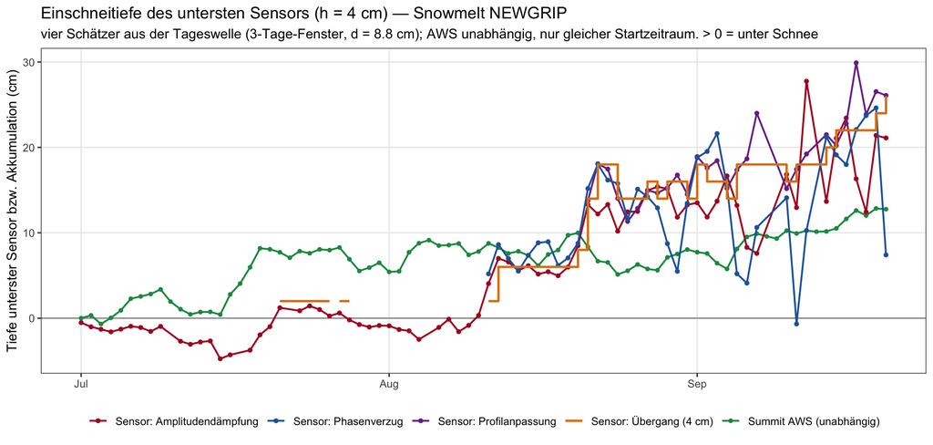

```r
h_bot <- min(fitA$hoehe_cm)
sub7  <- fitA |> filter(rA < 0.8, hoehe_cm < 60)
d_fix <- if (nrow(sub7) >= 2) 1/coef(lm(log(A) ~ hoehe_cm, data = sub7))[2] else
         sqrt(2*2.5e-7/om)*100

ser_dat <- series_diag |>
  mutate(hoehe_cm = (node - 1L) * 3L * s + rank_map[sensor] * s, ts = as.numeric(time))

perday <- function(dy, win = 3) {
  t0 <- as.POSIXct(paste0(dy, " 12:00:00"), tz = "UTC")
  w <- ser_dat |> filter(time >= t0 - win*43200, time <= t0 + win*43200)
  if (n_distinct(w$time) < 8) return(NULL)
  fa <- w |> group_by(hoehe_cm) |>
    summarise(cf = list(coef(lm(temp_C ~ sin(om*ts) + cos(om*ts)))), .groups = "drop") |>
    mutate(A = sapply(cf, function(c) sqrt(c[2]^2 + c[3]^2)),
           phi = sapply(cf, function(c) atan2(c[3], c[2]))) |> select(-cf)
  Aa <- median(fa$A[fa$hoehe_cm >= h_ref]); pa <- median(fa$phi[fa$hoehe_cm >= h_ref])
  b  <- fa |> filter(hoehe_cm == h_bot)
  if (!nrow(b)) return(NULL)
  lag <- (((pa - b$phi + pi) %% (2*pi)) - pi)/om
  # Der Phasenverzug ist nur aussagekräftig, wenn der Sensor überhaupt gedämpft
  # ist — bei freiem Sensor ist die Phasendifferenz Rauschen.
  zp <- if (b$A/Aa < 0.8) lag*om*d_fix else NA_real_
  # Dritter, unabhängiger Schätzer: Regression über das ganze Übergangsprofil.
  # ln(A/A_Luft) fällt linear mit der Höhe; die Höhe mit ln = 0 ist die
  # Schneeoberfläche. Nutzt alle teilgedämpften Sensoren (4 cm Abstand) statt
  # nur des untersten und braucht kein vorgegebenes d.
  tr <- fa |> mutate(rA = A/Aa) |> filter(rA > 0.12, rA < 0.9, hoehe_cm < 60)
  zpr <- NA_real_; dpr <- NA_real_
  if (nrow(tr) >= 3) {
    lf2 <- lm(log(rA) ~ hoehe_cm, data = tr)
    if (coef(lf2)[2] > 0) { dpr <- 1/coef(lf2)[2]
      zpr <- (-coef(lf2)[1]/coef(lf2)[2]) - h_bot }
  }
  # Vierter Schätzer, ohne Modell: der Übergang vom überhöhten Sensor (über der
  # Fläche) zum ersten gedämpften darunter. Auflösung = Knotenabstand, 4 cm.
  ueb <- fa |> mutate(rA = A/Aa) |> filter(rA > 1.05, hoehe_cm < h_ref)
  hue <- if (nrow(ueb)) min(ueb$hoehe_cm) else NA_real_
  gde <- fa |> mutate(rA = A/Aa) |> filter(rA < 0.95, hoehe_cm < hue)
  hgd <- if (nrow(gde)) max(gde$hoehe_cm) else NA_real_
  tibble(day = as.Date(dy), z_amp = d_fix*log(Aa/b$A), z_phase = zp,
         z_prof = zpr, n_prof = nrow(tr), d_prof = dpr,
         z_ueb = (hgd + hue)/2 - h_bot, A_air = Aa)
}
dseq <- seq(as.Date(min(ser_dat$time)) + 2, as.Date(max(ser_dat$time)) - 2, by = "1 day")
res  <- bind_rows(lapply(dseq, perday)) |> filter(A_air >= 2)

cols_s <- c(`Sensor: Amplitudendämpfung` = "#b2182b",
            `Sensor: Phasenverzug`       = "#2166ac",
            `Sensor: Profilanpassung`    = "#7b3294",
            `Sensor: Übergang (4 cm)`    = "#e08214",
            `Summit AWS (unabhängig)`    = "#1a9850")

# Die Sensor-Schätzer sind physikalisch nullreferenziert (Tiefe 0 = freier
# Sensor); nur die AWS hat einen willkürlichen Nullpunkt und wird auf den
# gleichen Startzeitraum gelegt (Median der ersten 3 Tage des Sensorfensters).
# Kein Fit aneinander.
aws_line <- NULL
if (exists("aws_raw") && !is.null(aws_raw) && "z_surf_combined" %in% names(aws_raw) && nrow(res)) {
  aws_line <- aws_raw |> mutate(day = as.Date(time)) |>
    filter(is.finite(z_surf_combined), day >= min(res$day), day <= max(res$day)) |>
    group_by(day) |> summarise(z = 100*mean(z_surf_combined), .groups = "drop")
  if (nrow(aws_line)) aws_line <- aws_line |>
    mutate(wert = z - median(head(z[order(day)], 3)))
}

p_abs <- ggplot(res) + geom_hline(yintercept = 0, colour = "grey60") +
  { if (!is.null(aws_line)) geom_line(data = aws_line, aes(day, wert,
      colour = "Summit AWS (unabhängig)"), linewidth = 0.7) } +
  { if (!is.null(aws_line)) geom_point(data = aws_line, aes(day, wert,
      colour = "Summit AWS (unabhängig)"), size = 1.1) } +
  geom_line(aes(day, z_amp,   colour = "Sensor: Amplitudendämpfung"), linewidth = 0.7) +
  geom_point(aes(day, z_amp,  colour = "Sensor: Amplitudendämpfung"), size = 1.2) +
  geom_line(aes(day, z_prof,  colour = "Sensor: Profilanpassung"), linewidth = 0.7) +
  geom_point(aes(day, z_prof, colour = "Sensor: Profilanpassung"), size = 1.2) +
  geom_line(aes(day, z_phase, colour = "Sensor: Phasenverzug"), linewidth = 0.7) +
  geom_point(aes(day, z_phase, colour = "Sensor: Phasenverzug"), size = 1.2) +
  geom_step(aes(day, z_ueb, colour = "Sensor: Übergang (4 cm)"), linewidth = 0.9) +
  scale_colour_manual(NULL, values = cols_s) + scale_x_date(NULL) +
  scale_y_continuous("Tiefe unterster Sensor bzw. Akkumulation (cm)") +
  labs(title = sprintf("Einschneitiefe des untersten Sensors (h = %d cm) — %s", h_bot, cfg$label),
       subtitle = sprintf("vier Schätzer aus der Tageswelle (3-Tage-Fenster, d = %.1f cm); AWS unabhängig, nur gleicher Startzeitraum. > 0 = unter Schnee", d_fix)) +
  theme_bw(11) + theme(legend.position = "bottom", panel.grid.minor = element_blank())

p_abs
```

```r
if (nrow(res) >= 5) {
  la <- tail(res, 1)
  cat(sprintf("Aktuell (%s): **%.1f cm** (Übergang, 4-cm-Raster), %.1f cm (Amplitude), %.1f cm (Profilanpassung), %.1f cm (Phase). Der Übergangsschätzer ist der einzige ohne Modellannahme; Amplitude und Profilanpassung weichen im Mittel um **%.1f** bzw. **%.1f cm** von ihm ab. Der Phasenverzug ist mit der aus der Amplitude bestimmten Dämpfungstiefe gerechnet und deshalb systematisch zu klein — siehe den Abschnitt zum Amplitudenprofil.\n",
              format(la$day, "%d.%m.%Y"), la$z_ueb, la$z_amp, la$z_prof, la$z_phase,
              median(abs(res$z_amp  - res$z_ueb), na.rm = TRUE),
              median(abs(res$z_prof - res$z_ueb), na.rm = TRUE)))
}
```

Aktuell (20.09.2026): **26.0 cm** (Übergang, 4-cm-Raster), 21.1 cm (Amplitude), 26.1 cm (Profilanpassung), 7.4 cm (Phase). Der Übergangsschätzer ist der einzige ohne Modellannahme; Amplitude und Profilanpassung weichen im Mittel um **1.4** bzw. **0.9 cm** von ihm ab. Der Phasenverzug ist mit der aus der Amplitude bestimmten Dämpfungstiefe gerechnet und deshalb systematisch zu klein — siehe den Abschnitt zum Amplitudenprofil.

### Zoom: der eingeschneite Bereich

Seit dem Einschneien der untersten Knoten lässt sich das Profil unter der Oberfläche direkt betrachten. Alle folgenden Darstellungen laufen in **Tiefe unter der Schneeoberfläche**, nicht in Kettenhöhe: die Oberfläche wandert im Betrachtungszeitraum um rund 20 cm, und jede Messung bekommt die Tiefe, die zu ihrem Tag gehört (Oberflächenlage aus dem Übergangsschätzer).

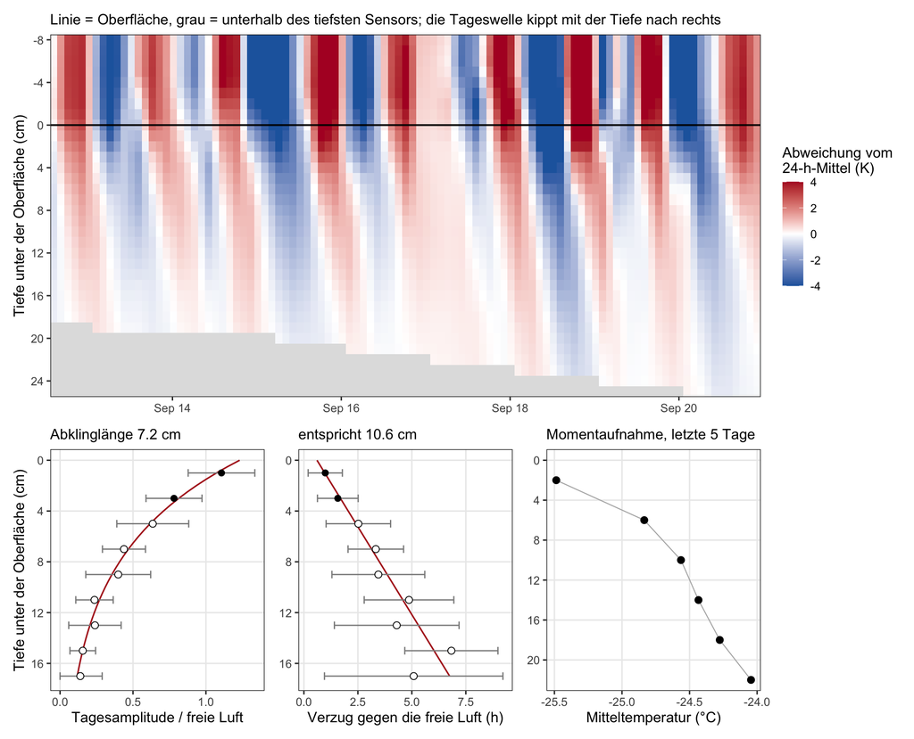

```r
# Oberflächenlage: der Übergangsschätzer liefert 2-cm-Stufen und nicht an jedem
# Tag einen Wert. Für die Tiefenkoordinate wird er auf jeden Tag interpoliert
# und geglättet, sonst fallen ganze Tage aus dem Hovmöller heraus.
sfc <- res |> transmute(day, h_surf = h_bot + z_ueb) |> filter(is.finite(h_surf))
alltage <- seq(min(sfc$day), max(sfc$day), by = "1 day")
hsi <- approx(as.numeric(sfc$day), sfc$h_surf, as.numeric(alltage), rule = 2)$y
if (length(alltage) >= 12)
  hsi <- as.numeric(predict(loess(hsi ~ as.numeric(alltage), span = 0.35)))
surf <- tibble(day = alltage, h_surf = hsi)

# Anomalie je Sensor gegen sein zentriertes 24-h-Mittel; damit tritt die
# Tageswelle hervor statt des saisonalen Gangs.
an <- ser_dat |> filter(hoehe_cm <= 80, time > max(time) - 12*86400) |>
  group_by(hoehe_cm) |> arrange(ts, .by_group = TRUE) |>
  mutate(anom = temp_C - sapply(ts, function(t0) mean(temp_C[abs(ts - t0) <= 43200]))) |>
  ungroup() |> mutate(day = as.Date(time)) |> inner_join(surf, by = "day") |>
  mutate(z = h_surf - hoehe_cm)

# Auf ein reguläres Gitter bringen: die Sensoren stehen 4 cm auseinander, die
# Oberfläche wandert, und die Telemetrie hat 4- und 8-Stunden-Abstände. Ohne
# Interpolation bleibt jede zweite Tiefenzeile und mancher Zeitschritt leer.
zg <- seq(-8, 26, by = 1)
gr1 <- an |> group_by(time) |> group_modify(function(x, k) {
  x <- x |> arrange(z); if (nrow(x) < 4) return(tibble())
  inb <- zg >= min(x$z) & zg <= max(x$z)
  tibble(z = zg[inb], anom = approx(x$z, x$anom, zg[inb])$y) }) |> ungroup() |>
  filter(is.finite(anom))
tt  <- sort(unique(as.numeric(gr1$time))); tg <- seq(min(tt), max(tt), by = 7200)
hovg <- gr1 |> group_by(z) |> group_modify(function(x, k) {
  x <- x |> arrange(time); u <- as.numeric(x$time)
  keep <- tg >= min(u) & tg <= max(u)
  tibble(ts = tg[keep], anom = approx(u, x$anom, tg[keep])$y) }) |> ungroup() |>
  mutate(time = as.POSIXct(ts, origin = "1970-01-01", tz = "UTC"))

p_h <- ggplot(hovg, aes(time, z, fill = pmax(pmin(anom, 4), -4))) +
  geom_tile(width = 7200, height = 1) +
  scale_fill_gradient2(name = "Abweichung vom\n24-h-Mittel (K)",
                       low = "#2166ac", mid = "white", high = "#b2182b",
                       limits = c(-4, 4)) +
  geom_hline(yintercept = 0, linewidth = 0.7) +
  scale_y_reverse("Tiefe unter der Oberfläche (cm)", breaks = seq(-8, 24, 4),
                  expand = c(0, 0)) +
  scale_x_datetime(NULL, expand = c(0, 0)) +
  labs(subtitle = "Linie = Oberfläche, grau = unterhalb des tiefsten Sensors; die Tageswelle kippt mit der Tiefe nach rechts") +
  theme_bw(base_size = 12) +
  theme(panel.grid = element_blank(),
        panel.background = element_rect(fill = "grey88", colour = NA))

# Für die Profile darunter wird der ganze Zeitraum genutzt, nicht nur die
# zwölf Tage des Hovmöllers.
dz <- ser_dat |> mutate(day = as.Date(time)) |> inner_join(surf, by = "day") |>
  mutate(z = h_surf - hoehe_cm) |> filter(z > -8, z < 26)

# (b) Amplitude und Verzug gegen die Tiefe, gebündelt über den ganzen Zeitraum.
# Der Fehler folgt aus der Kovarianz der beiden Harmonischen; unterhalb SNR 3
# ist die Phase nicht mehr bestimmt und die Punkte sind offen gezeichnet.
har <- function(x) { m <- lm(temp_C ~ sin(om*ts) + cos(om*ts), x)
  cf <- coef(m); V <- vcov(m)[2:3, 2:3]; A <- sqrt(cf[2]^2 + cf[3]^2)
  g <- c(cf[2], cf[3])/A; gp <- c(-cf[3], cf[2])/A^2
  tibble(A = A, sA = as.numeric(sqrt(t(g) %*% V %*% g)), phi = atan2(cf[3], cf[2]),
         sP = as.numeric(sqrt(t(gp) %*% V %*% gp)), Tm = mean(x$temp_C), n = nrow(x)) }
bins <- dz |> filter(z > 0) |> mutate(zbin = floor(z/2)*2 + 1) |> count(zbin) |>
  filter(n >= 40) |> pull(zbin)
pr <- bind_rows(lapply(bins, function(k)
  har(dz |> filter(z > 0, floor(z/2)*2 + 1 == k)) |> mutate(zbin = k)))
mr <- har(ser_dat |> filter(hoehe_cm >= h_ref))
pr <- pr |> mutate(rA = A/mr$A, lag_h = (((mr$phi - phi + pi) %% (2*pi)) - pi)/om/3600,
                   snr = A/sA, sP_h = sP/om/3600, gut = snr > 3)

fA <- lm(log(A) ~ zbin, pr, weights = snr^2)
fP <- lm(I(lag_h*3600) ~ zbin, pr, weights = 1/sP^2)
d_amp <- -1/coef(fA)[2]; d_pha <- 1/(coef(fP)[2]*om)

p_a <- ggplot(pr, aes(rA, zbin)) +
  geom_line(data = tibble(zbin = seq(0, max(pr$zbin), 0.5)) |>
              mutate(rA = exp(coef(fA)[1] + coef(fA)[2]*zbin)/mr$A),
            colour = "firebrick", linewidth = 0.6) +
  geom_errorbarh(aes(xmin = pmax(rA - sA/mr$A, 0), xmax = rA + sA/mr$A), height = 0.6,
                 colour = "grey55") +
  geom_point(aes(shape = gut), size = 2.4, fill = "white") +
  scale_shape_manual(values = c(`TRUE` = 16, `FALSE` = 21), guide = "none") +
  scale_y_reverse("Tiefe unter der Oberfläche (cm)", breaks = seq(0, 24, 4)) +
  scale_x_continuous("Tagesamplitude / freie Luft", limits = c(0, NA)) +
  labs(subtitle = sprintf("Abklinglänge %.1f cm", d_amp)) +
  theme_bw(base_size = 12) + theme(panel.grid.minor = element_blank())

p_p <- ggplot(pr, aes(lag_h, zbin)) +
  geom_line(data = tibble(zbin = seq(0, max(pr$zbin), 0.5)) |>
              mutate(lag_h = (coef(fP)[1] + coef(fP)[2]*zbin)/3600),
            colour = "firebrick", linewidth = 0.6) +
  geom_errorbarh(aes(xmin = lag_h - sP_h, xmax = lag_h + sP_h), height = 0.6,
                 colour = "grey55") +
  geom_point(aes(shape = gut), size = 2.4, fill = "white") +
  scale_shape_manual(values = c(`TRUE` = 16, `FALSE` = 21), guide = "none") +
  scale_y_reverse(NULL, breaks = seq(0, 24, 4)) +
  scale_x_continuous("Verzug gegen die freie Luft (h)") +
  labs(subtitle = sprintf("entspricht %.1f cm", d_pha)) +
  theme_bw(base_size = 12) + theme(panel.grid.minor = element_blank())

# Das Mitteltemperaturprofil darf NICHT aus den Tiefenklassen kommen: eine
# Tiefenklasse mischt verschiedene Wochen (ein Sensor lag erst spät tief), ihr
# Gradient wäre der Jahresgang, nicht das Profil. Deshalb eine Momentaufnahme
# der letzten Tage bei festen Kettenhöhen, umgerechnet mit der Oberfläche von
# heute.
h_now <- tail(sfc$h_surf, 1)
snap  <- ser_dat |> filter(time > max(time) - 5*86400) |>
  group_by(hoehe_cm) |> summarise(Tm = mean(temp_C), .groups = "drop") |>
  mutate(z = h_now - hoehe_cm) |> filter(z > 0, z < 26)
g_snap <- if (nrow(snap) >= 3) as.numeric(coef(lm(Tm ~ z, snap))[2]) else NA_real_
p_t <- ggplot(snap, aes(Tm, z)) +
  geom_path(colour = "grey70", linewidth = 0.4) + geom_point(size = 2.4) +
  scale_y_reverse(NULL, breaks = seq(0, 24, 4),
                  limits = c(max(c(pr$zbin, snap$z)), 0)) +
  scale_x_continuous("Mitteltemperatur (°C)") +
  labs(subtitle = "Momentaufnahme, letzte 5 Tage") +
  theme_bw(base_size = 12) + theme(panel.grid.minor = element_blank())

p_h / (p_a + p_p + p_t) + plot_layout(heights = c(1.5, 1))
```

Über den ganzen Zeitraum tiefenmitgeführt: Abklinglänge **7.2 cm** aus der Amplitude, **10.6 cm** aus dem Verzug (Verhältnis 1.46). Mit κ = k(ρ)/(ρ·c) und c = 1955 J/(kg·K) bei -20.1 °C entspricht das ρ = — bzw. 338 kg/m³. Belastbar (SNR > 3) sind die Klassen bis 3 cm Tiefe; darunter ist die Tagesamplitude kleiner als die Wetterstreuung, und die offenen Symbole zeigen Punkte, deren Phase nicht mehr bestimmt ist.

Das Mitteltemperaturprofil der letzten fünf Tage zeigt **+0.064 K/cm** über die obersten 22 cm: nach unten wärmer, die Sommerwärme steht noch im Firn. Es stammt aus einer Momentaufnahme bei festen Kettenhöhen, nicht aus den Tiefenklassen — eine Tiefenklasse mischt Messungen aus verschiedenen Wochen, ihr Temperaturgradient wäre der Jahresgang, nicht das Profil.